# R Notebook

# **Chapter 5 Logistic Regression**

**5.1 Prerequisites**

```r
# Helper packages
library(dplyr)     # for data wrangling
library(ggplot2)   # for awesome plotting
library(rsample)   # for data splitting

# Modeling packages
library(caret)     # for logistic regression modeling

# Model interpretability packages
library(vip)       # variable importance
```

An unordered factor is what is often called categorical data, it does not have a natural order. To represent this in R you can use an unordered factor: is.ordered(f) f <- factor(c(1,3,2,1,3)) f [1] 1 3 2 1 3 Levels: 1 2 3

is.ordered(f) [1] FALSE

If the factors have a natural ordering, often called ordinal or ordered categorical data, you can define this in R using an ordered factor. Note the < sign in the levels of an ordered factor.

f <- factor(c(1,3,2,1,3), ordered=TRUE) f [1] 1 3 2 1 3 Levels: 1 < 2 < 3

is.ordered(f) [1] TRUE

```r
library(modeldata) # data for some ML model
data("attrition")
df <- attrition %>% mutate_if(is.ordered, factor, ordered = FALSE)

# Create training (70%) and test (30%) sets for the
# rsample::attrition data.
set.seed(123)  # for reproducibility
churn_split <- initial_split(df, prop = .7, strata = "Attrition")
churn_train <- training(churn_split)
churn_test  <- testing(churn_split)
```

#**5.3 Simple logistic regression**

We will fit two logistic regression models in order to predict the probability of an employee attriting. The first predicts the probability of attrition based on their monthly income (MonthlyIncome) and the second is based on whether or not the employee works overtime (OverTime). The glm() function fits generalized linear models, a class of models that includes both logistic regression and simple linear regression as special cases. The syntax of the glm() function is similar to that of lm(), except that we must pass the argument family = “binomial” in order to tell R to run a logistic regression rather than some other type of generalized linear model (the default is family = “gaussian”, which is equivalent to ordinary linear regression assuming normally distributed errors).

```r
model1 <- glm(Attrition ~ MonthlyIncome, family = "binomial", data = churn_train)
model2 <- glm(Attrition ~ OverTime, family = "binomial", data = churn_train)
```

For model1, the estimated coefficient for MonthlyIncome is B1=-0.000130, which is negative, indicating that an increase in MonthlyIncome is associated with a decrease in the probability of attrition. Similarly, for model2, employees who work OverTime are associated with an increased probability of attrition compared to those that do not work OverTime.

```r
tidy(model1)
```

| term | estimate | std.error | statistic | p.value |
| --- | --- | --- | --- | --- |
| (Intercept) | -0.9236247934 | 0.1550905456 | -5.955391 | 2.594512e-09 |
| MonthlyIncome | -0.0001302806 | 0.0000264429 | -4.926867 | 8.355852e-07 |

```r
## # A tibble: 2 x 5
##   term           estimate std.error statistic       p.value
##   <chr>             <dbl>     <dbl>     <dbl>         <dbl>
## 1 (Intercept)   -0.924    0.155         -5.96 0.00000000259
## 2 MonthlyIncome -0.000130 0.0000264     -4.93 0.000000836
tidy(model2)
```

| term | estimate | std.error | statistic | p.value |
| --- | --- | --- | --- | --- |
| (Intercept) | -2.183802 | 0.1217895 | -17.930951 | 6.761317e-72 |
| OverTimeYes | 1.406394 | 0.1757048 | 8.004299 | 1.201490e-15 |

```r
## # A tibble: 2 x 5
##   term        estimate std.error statistic  p.value
##   <chr>          <dbl>     <dbl>     <dbl>    <dbl>
## 1 (Intercept)    -2.18     0.122    -17.9  6.76e-72
## 2 OverTimeYes     1.41     0.176      8.00 1.20e-15
```

As discussed earlier, it is easier to interpret the coefficients using an  
exp() transformation:

```r
exp(coef(model1))
```

```
  (Intercept) MonthlyIncome
    0.3970771     0.9998697
```

```r
exp(coef(model2))
```

```
(Intercept) OverTimeYes
  0.1126126   4.0812121
```

Many aspects of the logistic regression output are similar to those discussed for linear regression. For example, we can use the estimated standard errors to get confidence intervals as we did for linear regression in Chapter 4:

```r
confint(model1)
```

```
                      2.5 %        97.5 %
(Intercept)   -1.2267754960 -6.180062e-01
MonthlyIncome -0.0001849796 -8.107634e-05
```

```r
confint(model2)
```

```
                2.5 %    97.5 %
(Intercept) -2.430458 -1.952330
OverTimeYes  1.063246  1.752879
```

#**5.4 Multiple logistic regression**

```r
model3 <- glm(
  Attrition ~ MonthlyIncome + OverTime,
  family = "binomial",
  data = churn_train
  )

tidy(model3)
```

| term | estimate | std.error | statistic | p.value |
| --- | --- | --- | --- | --- |
| (Intercept) | -1.4296820006 | 1.763808e-01 | -8.105654 | 5.246248e-16 |
| MonthlyIncome | -0.0001392218 | 2.703737e-05 | -5.149235 | 2.615514e-07 |
| OverTimeYes | 1.4682839234 | 1.799996e-01 | 8.157150 | 3.430225e-16 |

#**5.5 Assessing model accuracy** #** BEST METHOD** With a basic understanding of logistic regression under our belt, similar to linear regression our concern now shifts to how well do our models predict. As in the last chapter, we’ll use caret::train() and fit three 10-fold cross validated logistic regression models. Extracting the accuracy measures (in this case, classification accuracy), we see that both cv_model1 and cv_model2 had an average accuracy of 83.88%. However, cv_model3 which used all predictor variables in our data achieved an average accuracy rate of 87.58%.

```r
set.seed(123)
cv_model1 <- train(
  Attrition ~ MonthlyIncome,
  data = churn_train,
  method = "glm",
  family = "binomial",
  trControl = trainControl(method = "cv", number = 10)
)

set.seed(123)
cv_model2 <- train(
  Attrition ~ MonthlyIncome + OverTime,
  data = churn_train,
  method = "glm",
  family = "binomial",
  trControl = trainControl(method = "cv", number = 10)
)

set.seed(123)
cv_model3 <- train(
  Attrition ~ .,
  data = churn_train,
  method = "glm",
  family = "binomial",
  trControl = trainControl(method = "cv", number = 10)
)

# extract out of sample performance measures
summary(
  resamples(
    list(
      model1 = cv_model1,
      model2 = cv_model2,
      model3 = cv_model3
    )
  )
)$statistics$Accuracy
```

```
            Min.   1st Qu.    Median      Mean   3rd Qu.      Max. NA's
model1 0.8349515 0.8349515 0.8365385 0.8388478 0.8431373 0.8446602    0
model2 0.8349515 0.8349515 0.8365385 0.8388478 0.8431373 0.8446602    0
model3 0.8365385 0.8495146 0.8792476 0.8757893 0.8907767 0.9313725    0
```

```r
# predict class
pred_class <- predict(cv_model3, churn_train)

# create confusion matrix
confusionMatrix(
  data = relevel(pred_class, ref = "Yes"),
  reference = relevel(churn_train$Attrition, ref = "Yes")
)
```

```
Confusion Matrix and Statistics

          Reference
Prediction Yes  No
       Yes  93  25
       No   73 839

               Accuracy : 0.9049
                 95% CI : (0.8853, 0.9221)
    No Information Rate : 0.8388
    P-Value [Acc > NIR] : 5.360e-10

                  Kappa : 0.6016

 Mcnemar's Test P-Value : 2.057e-06

            Sensitivity : 0.56024
            Specificity : 0.97106
         Pos Pred Value : 0.78814
         Neg Pred Value : 0.91996
             Prevalence : 0.16117
         Detection Rate : 0.09029
   Detection Prevalence : 0.11456
      Balanced Accuracy : 0.76565

       'Positive' Class : Yes
```

One thing to point out, in the confusion matrix above you will note the metric No Information Rate: 0.839. This represents the ratio of non-attrition vs. attrition in our training data (table(churn_train$Attrition) %>% prop.table()). Consequently, if we simply predicted “No” for every employee we would still get an accuracy rate of 83.9%. Therefore, our goal is to maximize our accuracy rate over and above this no information baseline while also trying to balance sensitivity and specificity. To that end, we plot the ROC curve (section 2.6) which is displayed in Figure 5.4. If we compare our simple model (cv_model1) to our full model (cv_model3), we see the lift achieved with the more accurate model.

```r
#install.packages("ROCR")
library(ROCR)

# Compute predicted probabilities
m1_prob <- predict(cv_model1, churn_train, type = "prob")$Yes
m3_prob <- predict(cv_model3, churn_train, type = "prob")$Yes

# Compute AUC metrics for cv_model1 and cv_model3
perf1 <- prediction(m1_prob, churn_train$Attrition) %>%
  performance(measure = "tpr", x.measure = "fpr")
perf2 <- prediction(m3_prob, churn_train$Attrition) %>%
  performance(measure = "tpr", x.measure = "fpr")

# Plot ROC curves for cv_model1 and cv_model3
plot(perf1, col = "black", lty = 2)
plot(perf2, add = TRUE, col = "blue")
```

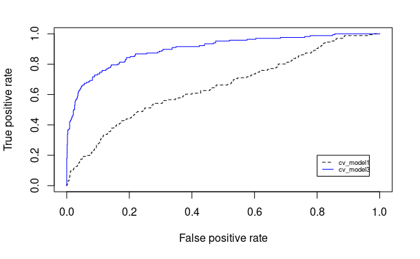

```r
legend(0.8, 0.2, legend = c("cv_model1", "cv_model3"),
       col = c("black", "blue"), lty = 2:1, cex = 0.6)
```

PLS was originally designed to be used for continuous features. Although you are not restricted from using PLS on categorical features, it is commonly advised to start with numeric features and explore alternative options for categorical features (i.e. ordinal encode, label encode, factor analysis.

#**LOGISTIC REGRESSION COMBINE WITH PLS**

```r
# Perform 10-fold CV on a PLS model tuning the number of PCs to
# use as predictors
set.seed(123)
cv_model_pls <- train(
  Attrition ~ .,
  data = churn_train,
  method = "pls",
  family = "binomial",
  trControl = trainControl(method = "cv", number = 5),
  preProcess = c("zv", "center", "scale"),
  tuneLength = 16
)

# Model with lowest RMSE
cv_model_pls$bestTune
```

|  | ncomp |
| --- | --- |
| 11 | 11 |

```r
##    ncomp
## 14    14

# results for model with lowest loss
cv_model_pls$results %>%
  dplyr::filter(ncomp == pull(cv_model_pls$bestTune))
```

| ncomp | Accuracy | Kappa | AccuracySD | KappaSD |
| --- | --- | --- | --- | --- |
| 11 | 0.879634 | 0.4098723 | 0.01227137 | 0.07741048 |

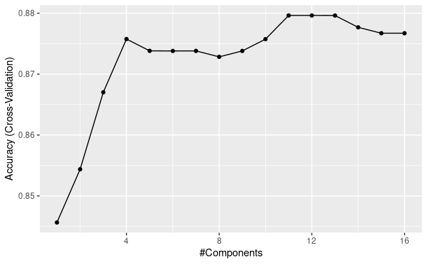

```r
##   ncomp  Accuracy     Kappa AccuracySD   KappaSD
## 1    14 0.8757518 0.3766944 0.01919777 0.1142592

# Plot cross-validated RMSE
ggplot(cv_model_pls)
```

#**5.7 Feature interpretation**

Similar to linear regression, once our preferred logistic regression model is identified, we need to interpret how the features are influencing the results. As with normal linear regression models, variable importance for logistic regression models can be computed using the absolute value of the  
z -statistic for each coefficient (albeit with the same issues previously discussed). Using vip::vip() we can extract our top 20 influential variables. Figure 5.6 illustrates that OverTime is the most influential followed by JobSatisfaction, and EnvironmentSatisfaction.

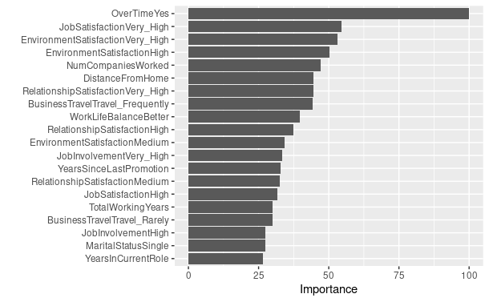

```r
vip(cv_model3, num_features = 20)
```

#**5.8 Final thoughts**

Logistic regression provides an alternative to linear regression for binary classification problems. However, similar to linear regression, logistic regression suffers from the many assumptions involved in the algorithm (i.e. linear relationship of the coefficient, multicollinearity). Moreover, often we have more than two classes to predict which is commonly referred to as multinomial classification. Although multinomial extensions of logistic regression exist, the assumptions made only increase and, often, the stability of the coefficient estimates (and therefore the accuracy) decrease. Future chapters will discuss more advanced algorithms that provide a more natural and trustworthy approach to binary and multinomial classification prediction.

```r
library(modeldata) # data for some ML model
data("attrition")
# mutate_if() is particularly useful for transforming variables from
# one type to another
df <- attrition %>% mutate_if(is.ordered, factor, ordered = FALSE)
df <- attrition %>% mutate_if(is.ordered, factor, ordered = FALSE)

# Create training (70%) and test (30%) sets for the
# rsample::attrition data. Use set.seed for reproducibility
set.seed(123)
churn_split <- initial_split(df, prop = .7, strata = "Attrition")
train <- training(churn_split)
test  <- testing(churn_split)

# train logistic regression model
set.seed(123)
glm_mod <- train(
  Attrition ~ .,
  data = train,
  method = "glm",
  family = "binomial",
  preProc = c("zv", "center", "scale"),
  trControl = trainControl(method = "cv", number = 10)
  )

# train regularized logistic regression model
set.seed(123)
penalized_mod <- train(
  Attrition ~ .,
  data = train,
  method = "glmnet",
  family = "binomial",
  preProc = c("zv", "center", "scale"),
  trControl = trainControl(method = "cv", number = 10),
  tuneLength = 10
  )

# extract out of sample performance measures
summary(resamples(list(
  logistic_model = glm_mod,
  penalized_model = penalized_mod
  )))$statistics$Accuracy
```

```
                     Min.   1st Qu.    Median      Mean   3rd Qu.      Max. NA's
logistic_model  0.8365385 0.8495146 0.8792476 0.8757893 0.8907767 0.9313725    0
penalized_model 0.8446602 0.8759280 0.8834951 0.8835759 0.8915469 0.9411765    0
```

```r
##                      Min.   1st Qu.    Median      Mean   3rd Qu.
## logistic_model  0.8365385 0.8495146 0.8792476 0.8757893 0.8907767
## penalized_model 0.8446602 0.8759280 0.8834951 0.8835759 0.8915469
##                      Max. NA's
## logistic_model  0.9313725    0
## penalized_model 0.9411765    0
```

#**Chapter 7 Multivariate Adaptive Regression Splines** #BESTMODEL

```r
# Helper packages
library(recipes)  # for feature engineering
library(rsample) # for resamples  (initial_split)
# Modeling packages
library(glmnet)   # for implementing regularized regression
library(caret)    # for automating the tuning process
library(earth)     # for fitting MARS models
# Model interpretability packages
library(vip)       # for variable importance
library(pdp)       # for variable relationships
#data for some ML model
library(modeldata) # data for some ML model
data("attrition")
# mutate_if() is particularly useful for transforming variables from
# one type to another
df <- attrition %>% mutate_if(is.ordered, factor, ordered = FALSE)

# Create training (70%) and test (30%) sets for the rsample::attrition data.
# Use set.seed for reproducibility
set.seed(123)
churn_split <- rsample::initial_split(df, prop = .7, strata = "Attrition")
churn_train <- rsample::training(churn_split)
churn_test  <- rsample::testing(churn_split)

# for reproducibiity
set.seed(123)

# cross validated model
tuned_mars <- train(
  x = subset(churn_train, select = -Attrition),
  y = churn_train$Attrition,
  method = "earth",
  trControl = trainControl(method = "cv", number = 5),
  tuneGrid = hyper_grid
)

# best model
tuned_mars$bestTune
```

|  | nprune | degree |
| --- | --- | --- |
| 3 | 23 | 1 |

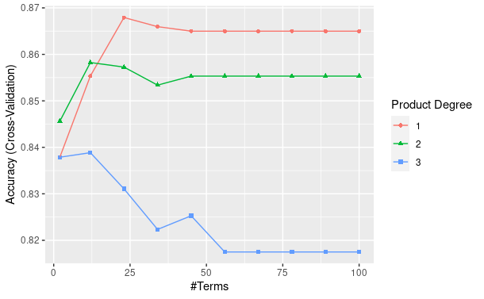

```r
##   nprune degree
## 2     12      1

# plot results
ggplot(tuned_mars)
```

However, comparing our MARS model to the previous linear models (logistic regression and regularized regression), we do not see any improvement in our overall accuracy rate.

#**Chapter 8 K-Nearest Neighbors**

K-nearest neighbor (KNN) is a very simple algorithm in which each observation is predicted based on its “similarity” to other observations. Unlike most methods in this book, KNN is a memory-based algorithm and cannot be summarized by a closed-form model. This means the training samples are required at run-time and predictions are made directly from the sample relationships. Consequently, KNNs are also known as lazy learners (Cunningham and Delany 2007) and can be computationally inefficient. However, KNNs have been successful in a large number of business problems (see, for example, Jiang et al. (2012) and Mccord and Chuah (2011)) and are useful for preprocessing purposes as well (as was discussed in Section 3.3.2).

```r
#Do parallel
library(doParallel)
cl <-makePSOCKcluster(5)
registerDoParallel(cl)
# Helper packages
library(recipes)  # for feature engineering
library(rsample) # for resamples  (initial_split)
# Modeling packages
library(glmnet)   # for implementing regularized regression
library(caret)    # for automating the tuning process, KNN model
library(earth)     # for fitting MARS models
# Model interpretability packages
library(vip)       # for variable importance
library(pdp)       # for variable relationships
#data for some ML model
library(modeldata) # data for some ML model
data("attrition")
# mutate_if() is particularly useful for transforming variables from
# one type to another
df <- attrition %>% mutate_if(is.ordered, factor, ordered = FALSE)

# Create training (70%) and test (30%) sets for the rsample::attrition data.
# Use set.seed for reproducibility
set.seed(123)
churn_split <- rsample::initial_split(df, prop = .7, strata = "Attrition")
churn_train <- rsample::training(churn_split)
churn_test  <- rsample::testing(churn_split)
```

#**8.3 Choosing k** When using KNN for classification, it is best to assess odd numbers for  
k to avoid ties in the event there is equal proportion of response levels (i.e. when k = 2 one of the neighbors could have class “0” while the other neighbor has class “1”).

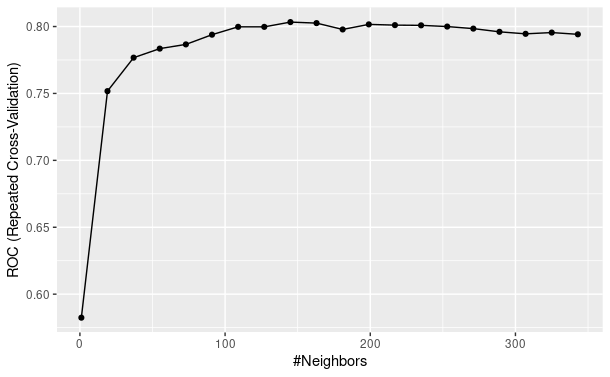

```r
# Create blueprint
blueprint <- recipe(Attrition ~ ., data = churn_train) %>%
  step_nzv(all_nominal()) %>%
  step_integer(contains("Satisfaction")) %>%
  step_integer(WorkLifeBalance) %>%
  step_integer(JobInvolvement) %>%
  step_dummy(all_nominal(), -all_outcomes(), one_hot = TRUE) %>%
  step_center(all_numeric(), -all_outcomes()) %>%
  step_scale(all_numeric(), -all_outcomes())

# Create a resampling method
cv <- trainControl(
  method = "repeatedcv",
  number = 5, #10
  repeats = 3, #5
  classProbs = TRUE,
  summaryFunction = twoClassSummary
)

# Create a hyperparameter grid search
hyper_grid <- expand.grid(
  k = floor(seq(1, nrow(churn_train)/3, length.out = 20))
)

# Fit knn model and perform grid search
knn_grid <- train(
  blueprint,
  data = churn_train,
  method = "knn",
  trControl = cv,
  tuneGrid = hyper_grid,
  metric = "ROC"
)

ggplot(knn_grid)
```

Figure 8.3: Cross validated search grid results for Attrition training data where 20 values between 1 and 343 are assessed for k. When k = 1, the predicted value is based on a single observation that is closest to the target sample and when k = 343, the predicted value is based on the response with the largest proportion for 1/3 of the training sample.

[output not shown]

[output cut: 10 more lines]